# W11 期中 LAB：重製真實研究分析

心理教育統計 2026

授課教師：陳紹慶 | e-mail: csc2009@mail.tcu.edu.tw

2026/05/11

# 本日LAB 須知

- 限用人社院電腦教室桌機安裝的**jamovi**及**Word**進行。
- LAB作業開始顯示後，截止時間未到前，擅自離開教室視為放棄。
- 上傳截止之前，務必確認指定檔案符合格式，未上傳或上傳不完整，**無更新機會**。

## LAB流程

| 時段 | 時長 | 模式 | 內容 |
| --- | --- | --- | --- |
| 說明與示範 | 60 分 | Open Book | 研究背景介紹 + jamovi 操作示範 |
| **Part A 限時測驗** | **10 分** | **Closed Book** | **Google Form 作答** |
| Part B & C 實作 | 60 分 | Open Book | jamovi 分析 + 詮釋報告 |

## LAB內容

| 部分 | 內容 | 配分 | 繳交方式 |
| --- | --- | --- | --- |
| **Part A** | 觀念測驗（10 題選擇） | 20 | Google Form（自動記錄） |
| **Part B** | jamovi 資料分析 | 50 | `學號_姓名_W11_Lab.omv` |
| **Part C** | 詮釋報告 | 30 | `學號_姓名_W11_Report.docx` |

## 限時LAB作業

- 5/11 10:20 AM 會準時出現在課程google classroom
- Part A在正式開始後10分鐘內限時作答 -> 10:30 AM 不接受作答
  - **不可查閱任何資訊**
  - **繳交送出後顯示答題狀況**
- LAB作業於10:30 AM ~ 11:30 AM間完成 -> 11:30 AM 不接受上傳
  - **可查閱資訊**

## jamovi 報表設定

- 界面右上角開啟

[figure not shown]

# 來源研究

## Zhang et al. (2024)

**研究問題**：不同教學影片格式，對學習效果與自我評估準確度的影響？

**三組教學條件**（N = 63）：

| condition | 組別 |
| --- | --- |
| 0 | 靜態投影片（Static Slides） |
| 2 | 無手繪圖（Drawing Only） |
| 1 | 顯手繪圖（Drawing + Hand） |

> Zhang, Y., Guo, X. H., Son, J. Y., Blank, I. A., & Stigler, J. W. (2024). *Memory & Cognition*. https://doi.org/10.3758/s13421-024-01526-7

## 關鍵測量變項

**前測（Pre_sum）**：學習前的基礎概念測驗

**後測（Post_sum）**：學習後的成效測驗，最高 19 分

**自評理解度（self_understand）**：學習後自評對內容的理解程度（0–100）

## 核心分析：學習成效自評準確度（JOL Accuracy）

$$\text{JOL_accuracy} =
\text{self_understand} - (\frac{\text{Post_sum}}{19} \times
100)$$

| 結果 | 意義 |
| --- | --- |
| 正值 | 高估（自評 > 實際表現） |
| 負值 | 低估（自評 < 實際表現） |
| **0** | **完全準確** |

**研究問題**：那一種教學方式的學生，自我評估學習成效最準確？

## 本日任務

> 使用真實資料 `W11_Study2.csv` 重製並驗證論文的統計報告

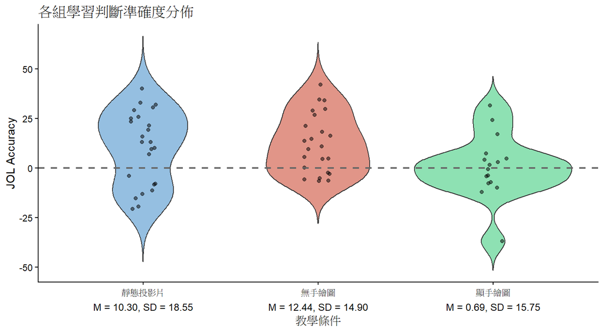

> 原始論文PDF p. 11

“We also tested, using one-sample t-tests, whether each group’s average judgments of learning were significantly different from 0. The Static Slides group significantly overestimated their learning (*t*(23) = 2.72, *p* = .012), as did the Drawing Only group (*t*(22) = 4.00, *p* < .001). The Drawing+Hand group’s judgment of learning did not significantly differ from 0 (*t*(15) = 0.18, *p* = .863).”

# Part B + C 概覽

## Part B：jamovi 分析任務

| 任務 | 操作 |
| --- | --- |
| B1 | 設定變項類型 + 建立計算變項 `JOL_accuracy` |
| B2 | 分組描述統計（M, SD, Median, Min, Max） |
| B3 | 分組小提琴圖 |
| B4 | 各組常態性評估（Q-Q Plot + Shapiro-Wilk） |
| B5 | 各組 95% CI + 單一樣本 *t* 檢定（H₀: μ = 0），APA 格式報告 |

> 詳細操作指引請見報告模板（`W11_Report_Template.docx`）

## Part C：詮釋報告

三道反思問題（寫入 `.docx`）：

**C1**（約 100 字）：根據各組 95% CI，哪一組包含 0？「CI 包含 0」代表什麼？

**C2**（約 100 字）：哪些組顯著高估學習成效（*p* < .05）？哪組自評最準確？

**C3**（約 200 字）：「學得最好的那組」同時也是「自評最準確」——你如何解釋這個現象？對教學設計有什麼啟示？

## 繳交規範

**截止時間**： Google Classroom設定之截止時間前上傳

| 項目 | 命名格式 |
| --- | --- |
| OMV 分析檔 | `學號_姓名_W11_Lab.omv` |
| 報告 | `學號_姓名_W11_Report.docx` |

> Part A（Google Form）系統自動記錄，**不需另外繳交**

# 期中LAB 試題分析

📊 **→ W11 試題分析報告**

*點擊連結查看全班答題情況、分組統計與各題得分率*